# 相關分析

wuyijin

2019年2月25日

- 相關分析
  - 測量兩個變數間關係強弱的方法
  - 說明兩變數之間關係或關聯的強度與方 向，但不能以此說明兩變數有因果關係(一個變數引起 另一個變數的變化)
  - 準備資料 - ad.csv(最近四個月廣告支出與銷售收異的資料(以 百萬美元為單位))
    - month：月份
    - out：廣告支出
    - inprice：銷售收異

  ```r
      ad <- read.csv("https://raw.githubusercontent.com/yijinwu1/R/master/excel/ad.csv")
      str(ad)
  ```

  ```
  ## 'data.frame':    4 obs. of  3 variables:
  ##  $ month  : int  7 8 9 10
  ##  $ out    : int  2 1 3 4
  ##  $ inprice: int  7 3 8 10
  ```

  - 繪製散佈圖(scatter diagram)呈現，水平軸(X-自變數)、垂直軸(Y-應變數)。標示出數軸的值域範圍。

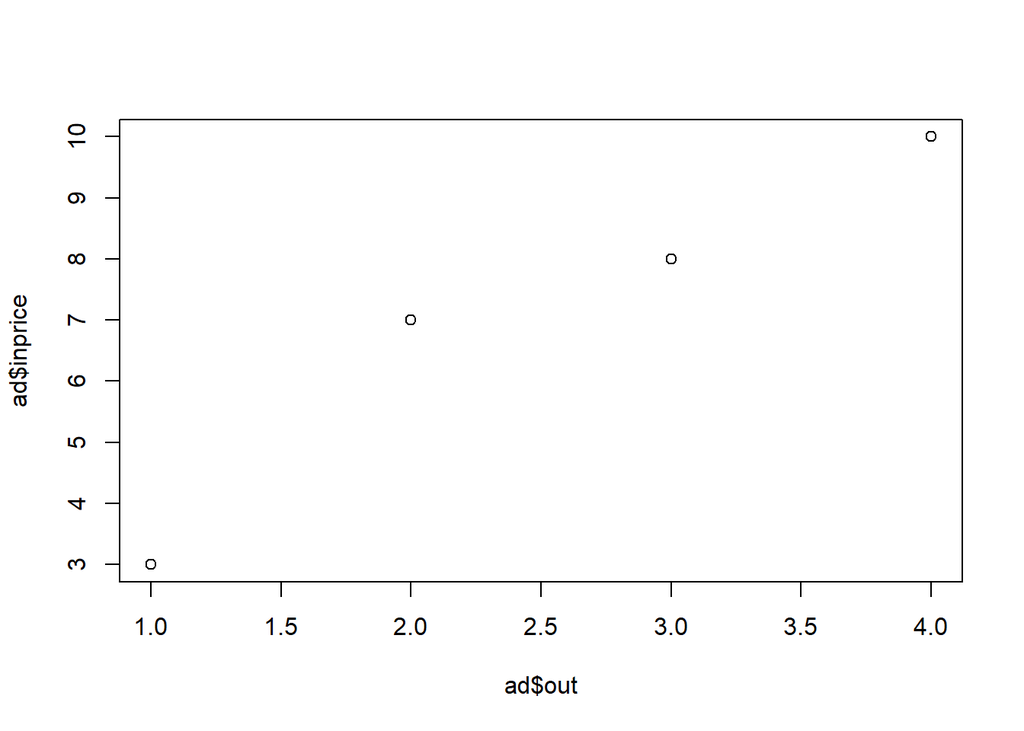

  ```r
    plot(ad$out,ad$inprice)
  ```

  - 相關係數(coefficient of correlation)
    - 由Pearson所創建，用於描述兩組數值變數 (區間尺度或比例尺度)間關係的強度，一般用r來表 示。
    - 相關係數的範圍在-1與1之間
    - 正負符號代表變數間關係的方向。正稱為正相關，表 示兩變數的關係是正向的(自變數大(小)應變數就大 (小))；負則稱為負相關，意指兩變數的關係是反向的 (自變數大(小)應變數就小(大))
    - 數值大小則為相關性的強弱。當數值越接近1，表示相 關性越高；若數值越接近0，則相關性越低

  ```r
    library("tidyverse")
    library(reshape2)
    #相關係數
    cor(ad)
  ```

  ```
  ##             month       out   inprice
  ## month   1.0000000 0.8000000 0.6139406
  ## out     0.8000000 1.0000000 0.9647638
  ## inprice 0.6139406 0.9647638 1.0000000
  ```

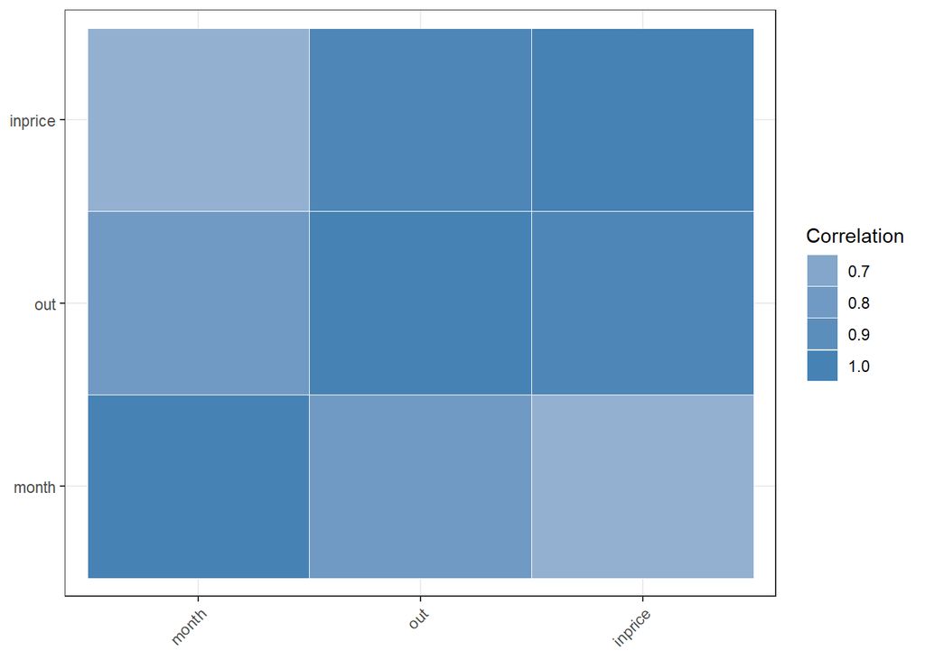

  ```r
    #相關係數熱圖
    ggplot(melt(cor(ad)), aes(Var1, Var2)) +
      geom_tile(aes(fill = value), colour = "white") +
      scale_fill_gradient2(low = "firebrick4", high = "steelblue", mid = "white", midpoint = 0) +
      guides(fill=guide_legend(title="Correlation")) +
      theme_bw() +
      theme(axis.text.x = element_text(angle = 45, hjust = 1, vjust = 1),
      axis.title = element_blank())
  ```

  ```r
    #相關係數r
    r <- cor(ad$out,ad$inprice)
    r2 <- r^2
    r2
  ```

  ```
  ## [1] 0.9307692
  ```

  ```r
    #相關係數t檢定
    cor.test(ad$out,ad$inprice)
  ```

  ```
  ##
  ##  Pearson's product-moment correlation
  ##
  ## data:  ad$out and ad$inprice
  ## t = 5.1854, df = 2, p-value = 0.03524
  ## alternative hypothesis: true correlation is not equal to 0
  ## 95 percent confidence interval:
  ##  0.05051995 0.99928854
  ## sample estimates:
  ##       cor
  ## 0.9647638
  ```

  ```r
    #結論：二者的相關係數為0.9647638，p值為0.03524<0.05。故x和y是有相關性的。
  ```